# PCA

Pablo, Román, Sofia

14/5/2020

```r
# Este chung es para la compu de pablo porque con el codigo de arriba no me cargaba las librerias
library('factoextra')
library('gridExtra')
library('sf')
library('ggplot2')
library('tmap')
library('tmaptools')
library('leaflet')
library('dplyr')
```

```
## 'data.frame':    16 obs. of  6 variables:
##  $ X1: num  0.3628 0.3042 0.0572 0.2584 0.3408 ...
##   ..- attr(*, "descripcion")= chr "Ingresos Inferiores. "
##  $ X2: num  0.1272 0.0713 0.0426 0.0741 0.1097 ...
##   ..- attr(*, "descripcion")= chr "Carencia de Alimentos."
##  $ X3: num  0.181 0.144 0.11 0.169 0.169 ...
##   ..- attr(*, "descripcion")= chr "Carencia de Salud."
##  $ X4: num  0.00795 0.02209 0.01745 0.0082 0.00142 ...
##   ..- attr(*, "descripcion")= chr "Personal medico"
##  $ X5: num  50.2 71.9 53.5 16.2 52 ...
##   ..- attr(*, "descripcion")= chr "Remuneracion (miles de pesos)"
##  $ X6: num  10.8 11.1 13.8 12.2 11.3 11.9 10.7 11.3 10.2 10.3 ...
##   ..- attr(*, "descripcion")= chr "Promedio años de escolaridad"
```

```
##                               X1         X2        X3          X4
## Alvaro Obregon        0.36277937 0.12722839 0.1810443 0.007952191
## Azcapotzalco          0.30422755 0.07126632 0.1443544 0.022086110
## Benito Juarez         0.05720672 0.04255707 0.1096484 0.017445426
## Coyoacan              0.25844606 0.07414225 0.1694570 0.008195846
## Cuajimalpa de Morelos 0.34084749 0.10972574 0.1693621 0.001420512
## Cuauhtemoc            0.18690534 0.07831709 0.1849882 0.023469964
##                              X5   X6
## Alvaro Obregon         50.23054 10.8
## Azcapotzalco           71.91106 11.1
## Benito Juarez          53.49819 13.8
## Coyoacan               16.21091 12.2
## Cuajimalpa de Morelos  51.96161 11.3
## Cuauhtemoc            228.55753 11.9
```

## Calculo de los Componentes Principales

Para calcular los componentes principales, usaremos la matriz de correlación dado que las unidades de nuestras variables son distintas, a pesar de que la mayoria esten en terminos poblacionales.

```r
#solo para comparar y para fines graficos
z <- princomp(df,cor = T)
summary(z, loadings=T)
```

```
## Importance of components:
##                           Comp.1    Comp.2     Comp.3     Comp.4
## Standard deviation     2.0500145 0.8137100 0.70494883 0.55399915
## Proportion of Variance 0.7004266 0.1103540 0.08282548 0.05115251
## Cumulative Proportion  0.7004266 0.8107806 0.89360603 0.94475854
##                            Comp.5     Comp.6
## Standard deviation     0.52599054 0.23405704
## Proportion of Variance 0.04611101 0.00913045
## Cumulative Proportion  0.99086955 1.00000000
##
## Loadings:
##    Comp.1 Comp.2 Comp.3 Comp.4 Comp.5 Comp.6
## X1  0.449  0.116  0.415  0.243  0.211  0.713
## X2  0.371  0.307 -0.813  0.309
## X3  0.405  0.390        -0.806 -0.181
## X4 -0.395  0.531        -0.111  0.739
## X5 -0.380  0.619  0.200  0.249 -0.598  0.114
## X6 -0.442 -0.275 -0.349 -0.348 -0.134  0.684
```

Para eso scamos la matriz de correlacion $R$ que es la siguiente.

```r
(round(R <- cor(df),3))
```

```
##        X1     X2     X3     X4     X5     X6
## X1  1.000  0.580  0.730 -0.682 -0.641 -0.934
## X2  0.580  1.000  0.623 -0.504 -0.517 -0.632
## X3  0.730  0.623  1.000 -0.547 -0.517 -0.738
## X4 -0.682 -0.504 -0.547  1.000  0.713  0.633
## X5 -0.641 -0.517 -0.517  0.713  1.000  0.560
## X6 -0.934 -0.632 -0.738  0.633  0.560  1.000
```

Ahora para calcular las componentes principales encontraremos sus egienvecores.

```r
eig <- eigen(R)
(y <- round(eig$vectors,3))
```

```
##        [,1]   [,2]   [,3]   [,4]   [,5]   [,6]
## [1,] -0.449 -0.116  0.415 -0.243  0.211  0.713
## [2,] -0.371 -0.307 -0.813 -0.309 -0.043  0.097
## [3,] -0.405 -0.390  0.034  0.806 -0.181 -0.010
## [4,]  0.395 -0.531 -0.059  0.111  0.739  0.016
## [5,]  0.380 -0.619  0.200 -0.249 -0.598  0.114
## [6,]  0.442  0.275 -0.349  0.348 -0.134  0.684
```

Podemos ver que los componentes principales obtenidos de la matriz de correlación, son los siguientes.
$$\begin{array}{l}
Y_{1} = -0.449X_{1} - 0.371X_{2} - 0.405X_{3} + 0.395X_{4} + 0.380X_{5} + 0.442X_{6}\\
Y_{2} = -0.116X_{1} - 0.307X_{2} - 0.390X_{3} - 0.531X_{4} - 0.619X_{5} + 0.275X_{6}\\
Y_{3} = -0.415X_{1} + 0.813X_{2} - 0.034X_{3} + 0.059X_{4} - 0.200X_{5} + 0.349X_{6}\\
Y_{4} = -0.243X_{1} - 0.309X_{2} + 0.806X_{3} + 0.111X_{4} - 0.249X_{5} + 0.348X_{6}\\
Y_{5} = 0.211X_{1} - 0.043X_{2} - 0.181X_{3} + 0.739X_{4} - 0.598X_{5} - 0.135X_{6} \\
Y_{6} = 0.713X_{1} + 0.097X_{2} - 0.010X_{3} + 0.016X_{4} + 0.114X_{5} + 0.684X_{6}\\
\end{array}$$

## Graficas y Analisis

Haremos la grafica de codo correspondiente, para dererminar cuales son las componentes mas significativas. Para realizar esto, veremos que tanta varianza aporta cada componente principal, mediante el siguiente razonamiento.

$$\frac{\lambda_{k}}{p}$$
Donde $\lambda_k$ es la k-esima componente principal y p es la suma de la diagonal de la matriz de covarianza $R$.

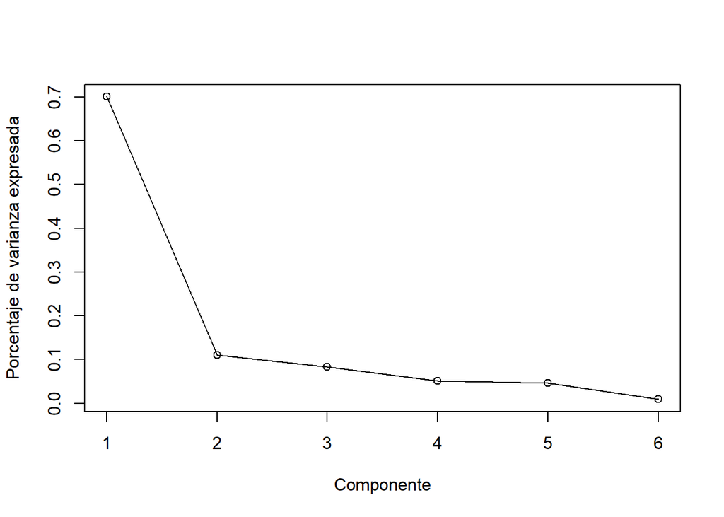

```
##         l1         l2         l3         l4         l5         l6
## 0.70042657 0.11035398 0.08282548 0.05115251 0.04611101 0.00913045
```

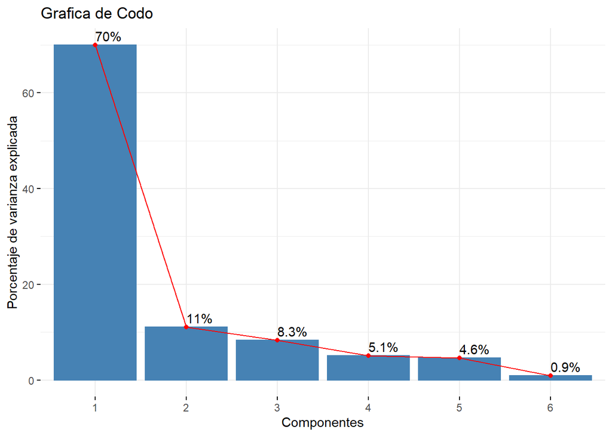

```r
fviz_screeplot(z,barfill = "steelblue",barcolor = "steelblue",linecolor = "red",addlabels =TRUE, xlab = "Componentes", ylab = "Porcentaje de varianza explicada", title = "Grafica de Codo")
```

Podemos ver que la primer componente principal $Y_1$ aporta un $70\%$ de variabilidad. Por lo cual podriamos decir que resume de buena manera los datos.

Al buscar la interpretacion del primer componente principal podemos destacar lo siguiente. Los coeficientes de las variables $X_1$, $X_2$,$X_3$ asignadas a *Ingresos Inferiores*, *Carencia de Alimentos*, *Carencia de Salud* tienen signo negativo. Contrastandolo con los coeficientes correspoindientes a las variables $X_4$, $X_5$,$X_6$ asignadas a *Personal medico* , *Remuneracion (miles de pesos)*, *Promedio años de escolaridad* tienen signo positivo. De donde podemos infererir que se pondera negativamente las variables que representan a una persona mas vulnerable. Y al contrario, se pondera positivamente las variables que representan a una persona menos vulnerable.

Podemos verlo de forma mas clara en la siguiente grafica. Podemos visualizar las CP como proyecciones en el espacio de las dos primeras componentes principales.

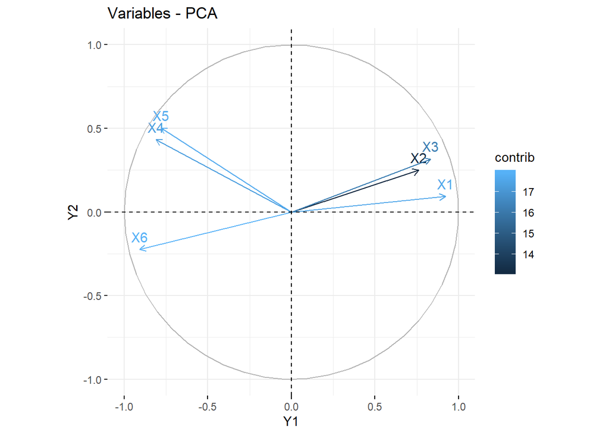

```r
fviz_pca_var(z,col.var="contrib", xlab = "Y1", ylab = "Y2")
```

Observamos que el conjunto de variables $X_2$, $X_3$ apuntan practicamente a la misma dirección mientras que $X_1$ apunta en el mismo sentido pero unos cuantos grados de diferencia. Por otro lado $X_4$, $X_5$,$X_6$ apuntan completamente en sentido opuesto y podemos ver que en particular $X_6$. Tambien, podemos ver que la variable $X_2$ es la que tiene una menor contribución.

Para ver que tanta aportacion proporcionan a las dimensiones cada una de las variables en la siguiente grafica.

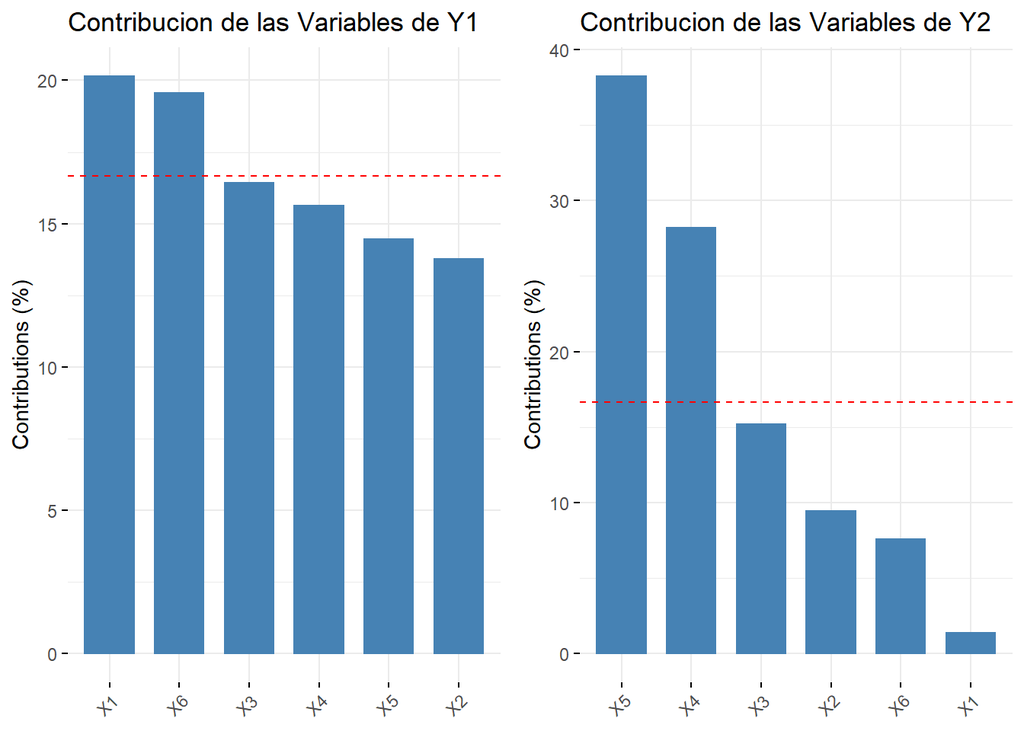

```r
gr1 <- fviz_contrib(z,choice = "var", axes = 1, title = "Contribucion de las Variables de Y1")
gr2 <- fviz_contrib(z,choice = "var", axes = 2, title = "Contribucion de las Variables de Y2")
grid.arrange(gr1, gr2, ncol = 2)
```

Podemos ver que para la primer dimension las dos variables que mas aportan son $X_1$ y $X_6$ mientras que para la segunda dimension son las variables $X_5$ y $X_4$

Podemos graficar las dos primeras componentes principales y asociar las delegaciones para visualizar su distribución en la dirección de esas componentes.

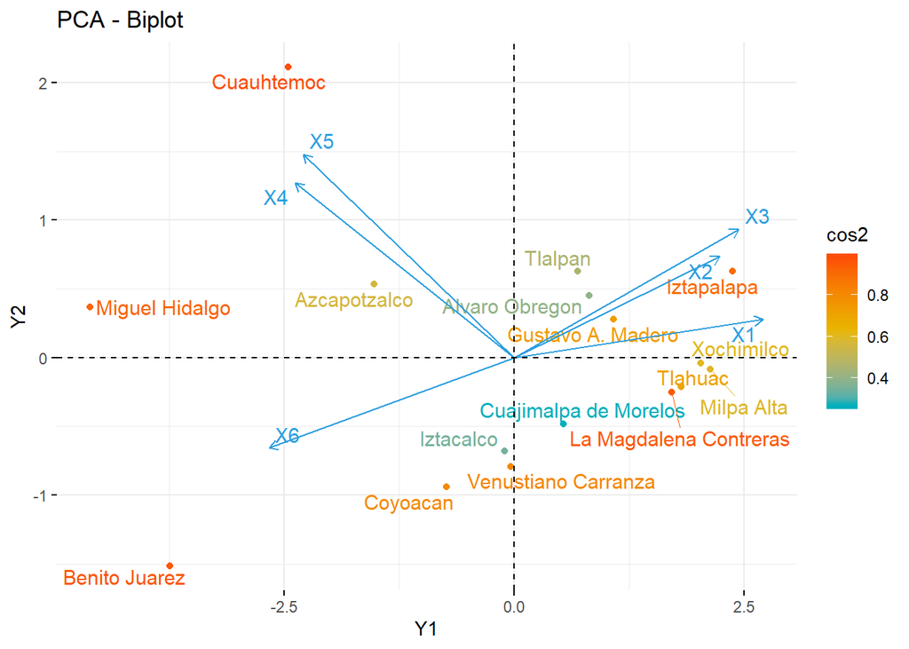

```r
fviz_pca_biplot(z,
                col.var = "#2E9FDF", # Variables color
                col.ind = "cos2", # Color by the quality of representation
                gradient.cols = c("#00AFBB", "#E7B800", "#FC4E07"),
                repel = TRUE,
                ylab = "Y2",
                xlab = "Y1"
                )
```

##Índice por delegación

```r
scores <- eig$vectors[,1]
ind <- as.matrix(df) %*% scores
IV <- round(100/as.numeric(ind),3)
```

```r
nomgeo <- c("Álvaro Obregón", "Azcapotzalco", "Benito Juárez", "Coyoacán", "Cuajimalpa de Morelos", "Cuauhtémoc", "Gustavo A. Madero","Iztacalco","Iztapalapa","La Magdalena Contreras", "Miguel Hidalgo", "Milpa Alta", "Tláhuac", "Tlalpan", "Venustiano Carranza", "Xochimilco")
index <- data.frame(nomgeo,IV)
```

##Semaforo de la ciudad de México

```r
mapa<-st_read('Data/alcaldias/alcaldias.shp',stringsAsFactors=FALSE)
str(mapa)
```

```
## Classes 'sf' and 'data.frame':   16 obs. of  6 variables:
##  $ nomgeo   : chr  "Milpa Alta" "Benito Juárez" "Gustavo A. Madero" "Coyoacán" ...
##  $ cve_mun  : chr  "009" "014" "005" "003" ...
##  $ cve_ent  : chr  "09" "09" "09" "09" ...
##  $ cvegeo   : chr  "09009" "09014" "09005" "09003" ...
##  $ municipio: chr  "9" "14" "5" "3" ...
##  $ geometry :sfc_POLYGON of length 16; first list element: List of 1
##   ..$ : num [1:469, 1:2] -99 -99 -99 -99 -99 ...
##   ..- attr(*, "class")= chr  "XY" "POLYGON" "sfg"
##  - attr(*, "sf_column")= chr "geometry"
##  - attr(*, "agr")= Factor w/ 3 levels "constant","aggregate",..: NA NA NA NA NA
##   ..- attr(*, "names")= chr  "nomgeo" "cve_mun" "cve_ent" "cvegeo" ...
```

```r
mapa_datos <- inner_join(mapa,index, by="nomgeo")
str(mapa_datos)
```

```
## Classes 'sf' and 'data.frame':   16 obs. of  7 variables:
##  $ nomgeo   : chr  "Milpa Alta" "Benito Juárez" "Gustavo A. Madero" "Coyoacán" ...
##  $ cve_mun  : chr  "009" "014" "005" "003" ...
##  $ cve_ent  : chr  "09" "09" "09" "09" ...
##  $ cvegeo   : chr  "09009" "09014" "09005" "09003" ...
##  $ municipio: chr  "9" "14" "5" "3" ...
##  $ IV       : num  24.68 3.792 14.688 8.809 0.921 ...
##  $ geometry :sfc_POLYGON of length 16; first list element: List of 1
##   ..$ : num [1:469, 1:2] -99 -99 -99 -99 -99 ...
##   ..- attr(*, "class")= chr  "XY" "POLYGON" "sfg"
##  - attr(*, "sf_column")= chr "geometry"
##  - attr(*, "agr")= Factor w/ 3 levels "constant","aggregate",..: NA NA NA NA NA NA
##   ..- attr(*, "names")= chr  "nomgeo" "cve_mun" "cve_ent" "cvegeo" ...
```

```r
tmap_mode("view")
```

```
## tmap mode set to interactive viewing
```

```r
tmap_last()
```

[interactive chart not shown]